# Exercise12

Jessica V

2024-04-22

```r
library(tidyverse)
library(readr)
library(dtplyr)
library(MASS)
library(AICcmodavg)
library(MuMIn)
```

```r
f<- "https://raw.githubusercontent.com/difiore/ada-2024-datasets/main/Mammal_lifehistories_v2.txt"
d <- read_tsv(f, col_names = TRUE, show_col_types = FALSE)
```

Do a bit of exploratory data analysis with this dataset, e.g., using the {skimr} package. Which of the variables are categorical and which are numeric?

Numerica columns are : “mass(g)” “gestation(mo)” “newborn(g)” “weaning(mo)” “wean mass(g)” “AFR(mo)” “max. life(mo)” “litter size” “litters/year” and “refs”.

Character columns are : “order” “family” “Genus” and “species”.

```r
head(d)
```

```
## # A tibble: 6 × 14
##   order        family       Genus species `mass(g)` `gestation(mo)` `newborn(g)`
##   <chr>        <chr>        <chr> <chr>       <dbl>           <dbl>        <dbl>
## 1 Artiodactyla Antilocapri… Anti… americ…     45375            8.13        3246.
## 2 Artiodactyla Bovidae      Addax nasoma…    182375            9.39        5480
## 3 Artiodactyla Bovidae      Aepy… melamp…     41480            6.35        5093
## 4 Artiodactyla Bovidae      Alce… busela…    150000            7.9        10167.
## 5 Artiodactyla Bovidae      Ammo… clarkei     28500            6.8         -999
## 6 Artiodactyla Bovidae      Ammo… lervia      55500            5.08        3810
## # ℹ 7 more variables: `weaning(mo)` <dbl>, `wean mass(g)` <dbl>,
## #   `AFR(mo)` <dbl>, `max. life(mo)` <dbl>, `litter size` <dbl>,
## #   `litters/year` <dbl>, refs <dbl>
```

```r
summary(d)
```

```
##     order              family             Genus             species
##  Length:1440        Length:1440        Length:1440        Length:1440
##  Class :character   Class :character   Class :character   Class :character
##  Mode  :character   Mode  :character   Mode  :character   Mode  :character
##
##
##
##     mass(g)          gestation(mo)       newborn(g)         weaning(mo)
##  Min.   :     -999   Min.   :-999.00   Min.   :   -999.0   Min.   :-999.00
##  1st Qu.:       50   1st Qu.:-999.00   1st Qu.:   -999.0   1st Qu.:-999.00
##  Median :      403   Median :   1.05   Median :      2.6   Median :   0.73
##  Mean   :   383577   Mean   :-287.25   Mean   :   6703.1   Mean   :-427.17
##  3rd Qu.:     7009   3rd Qu.:   4.50   3rd Qu.:     98.0   3rd Qu.:   2.00
##  Max.   :149000000   Max.   :  21.46   Max.   :2250000.0   Max.   :  48.00
##   wean mass(g)         AFR(mo)        max. life(mo)     litter size
##  Min.   :    -999   Min.   :-999.00   Min.   :-999.0   Min.   :-999.000
##  1st Qu.:    -999   1st Qu.:-999.00   1st Qu.:-999.0   1st Qu.:   1.000
##  Median :    -999   Median :   2.50   Median :-999.0   Median :   2.270
##  Mean   :   16049   Mean   :-408.12   Mean   :-490.3   Mean   : -55.634
##  3rd Qu.:      10   3rd Qu.:  15.61   3rd Qu.: 147.2   3rd Qu.:   3.835
##  Max.   :19075000   Max.   : 210.00   Max.   :1368.0   Max.   :  14.180
##   litters/year           refs
##  Min.   :-999.000   Min.   :1.000e+00
##  1st Qu.:-999.000   1st Qu.:1.160e+02
##  Median :   0.375   Median :1.229e+03
##  Mean   :-477.141   Mean   :1.055e+12
##  3rd Qu.:   1.155   3rd Qu.:1.242e+06
##  Max.   :   7.500   Max.   :1.368e+15
```

```r
#Here I view the classes of all of the columns
sapply(d, class)
```

```
##         order        family         Genus       species       mass(g)
##   "character"   "character"   "character"   "character"     "numeric"
## gestation(mo)    newborn(g)   weaning(mo)  wean mass(g)       AFR(mo)
##     "numeric"     "numeric"     "numeric"     "numeric"     "numeric"
## max. life(mo)   litter size  litters/year          refs
##     "numeric"     "numeric"     "numeric"     "numeric"
```

```r
#Here I extract only numeric columns
numericCols<-names(d)[sapply(d, is.numeric)]

numericCols
```

```
##  [1] "mass(g)"       "gestation(mo)" "newborn(g)"    "weaning(mo)"
##  [5] "wean mass(g)"  "AFR(mo)"       "max. life(mo)" "litter size"
##  [9] "litters/year"  "refs"
```

```r
#Here I extract only character columns
categoricalCols<-names(d)[sapply(d, is.character)]

categoricalCols
```

```
## [1] "order"   "family"  "Genus"   "species"
```

# Challenge

#Step 1

Replace all values of -999 (the authors’ code for missing data) with NA.

```r
d[d== -999] <- NA
head(d)
```

```
## # A tibble: 6 × 14
##   order        family       Genus species `mass(g)` `gestation(mo)` `newborn(g)`
##   <chr>        <chr>        <chr> <chr>       <dbl>           <dbl>        <dbl>
## 1 Artiodactyla Antilocapri… Anti… americ…     45375            8.13        3246.
## 2 Artiodactyla Bovidae      Addax nasoma…    182375            9.39        5480
## 3 Artiodactyla Bovidae      Aepy… melamp…     41480            6.35        5093
## 4 Artiodactyla Bovidae      Alce… busela…    150000            7.9        10167.
## 5 Artiodactyla Bovidae      Ammo… clarkei     28500            6.8           NA
## 6 Artiodactyla Bovidae      Ammo… lervia      55500            5.08        3810
## # ℹ 7 more variables: `weaning(mo)` <dbl>, `wean mass(g)` <dbl>,
## #   `AFR(mo)` <dbl>, `max. life(mo)` <dbl>, `litter size` <dbl>,
## #   `litters/year` <dbl>, refs <dbl>
```

#Step 2

Drop the variables “litter size” and “refs”.

```r
colnames(d)
```

```
##  [1] "order"         "family"        "Genus"         "species"
##  [5] "mass(g)"       "gestation(mo)" "newborn(g)"    "weaning(mo)"
##  [9] "wean mass(g)"  "AFR(mo)"       "max. life(mo)" "litter size"
## [13] "litters/year"  "refs"
```

```r
newd <- d[, -c(12,14)]

colnames(newd)
```

```
##  [1] "order"         "family"        "Genus"         "species"
##  [5] "mass(g)"       "gestation(mo)" "newborn(g)"    "weaning(mo)"
##  [9] "wean mass(g)"  "AFR(mo)"       "max. life(mo)" "litters/year"
```

#Step 3

Log transform all of the other numeric variables.

```r
lognewd <- newd %>%
 mutate(across(where(is.numeric), ~log(.+1)))

head(lognewd)
```

```
## # A tibble: 6 × 12
##   order        family       Genus species `mass(g)` `gestation(mo)` `newborn(g)`
##   <chr>        <chr>        <chr> <chr>       <dbl>           <dbl>        <dbl>
## 1 Artiodactyla Antilocapri… Anti… americ…      10.7            2.21         8.09
## 2 Artiodactyla Bovidae      Addax nasoma…      12.1            2.34         8.61
## 3 Artiodactyla Bovidae      Aepy… melamp…      10.6            1.99         8.54
## 4 Artiodactyla Bovidae      Alce… busela…      11.9            2.19         9.23
## 5 Artiodactyla Bovidae      Ammo… clarkei      10.3            2.05        NA
## 6 Artiodactyla Bovidae      Ammo… lervia       10.9            1.81         8.25
## # ℹ 5 more variables: `weaning(mo)` <dbl>, `wean mass(g)` <dbl>,
## #   `AFR(mo)` <dbl>, `max. life(mo)` <dbl>, `litters/year` <dbl>
```

#Step 4

Regress the age [gestation(mo), weaning(mo), AFR(mo), and max. life(mo)] and mass [newborn(g) and wean mass(g)] variables on overall body mass(g) and add the residuals to the dataframe as new variables (relGest, relWean, relAFR, relLife, relNewbornMass, and relWeaningMass).

```r
colnames(newd)
```

```
##  [1] "order"         "family"        "Genus"         "species"
##  [5] "mass(g)"       "gestation(mo)" "newborn(g)"    "weaning(mo)"
##  [9] "wean mass(g)"  "AFR(mo)"       "max. life(mo)" "litters/year"
```

```r
age <- lm(cbind(`gestation(mo)`, `weaning(mo)`, `AFR(mo)`, `max. life(mo)`) ~ `mass(g)`, data=newd, na.action=na.exclude)

mass <- lm(cbind(`newborn(g)`, `wean mass(g)`) ~ `mass(g)`, data =newd, na.action=na.exclude)

newd$relGest <- residuals(age)[, "gestation(mo)"]

newd$relWean <- residuals(age)[, "weaning(mo)"]

newd$relAFR <- residuals(age)[, "AFR(mo)"]

newd$relLife <- residuals(age)[,"max. life(mo)"]

newd$relNewbornMass <- residuals(mass)[,"newborn(g)"]

newd$relWeaningMass <- residuals(mass)[,"wean mass(g)"]

head(newd)
```

```
## # A tibble: 6 × 18
##   order        family       Genus species `mass(g)` `gestation(mo)` `newborn(g)`
##   <chr>        <chr>        <chr> <chr>       <dbl>           <dbl>        <dbl>
## 1 Artiodactyla Antilocapri… Anti… americ…     45375            8.13        3246.
## 2 Artiodactyla Bovidae      Addax nasoma…    182375            9.39        5480
## 3 Artiodactyla Bovidae      Aepy… melamp…     41480            6.35        5093
## 4 Artiodactyla Bovidae      Alce… busela…    150000            7.9        10167.
## 5 Artiodactyla Bovidae      Ammo… clarkei     28500            6.8           NA
## 6 Artiodactyla Bovidae      Ammo… lervia      55500            5.08        3810
## # ℹ 11 more variables: `weaning(mo)` <dbl>, `wean mass(g)` <dbl>,
## #   `AFR(mo)` <dbl>, `max. life(mo)` <dbl>, `litters/year` <dbl>,
## #   relGest <dbl>, relWean <dbl>, relAFR <dbl>, relLife <dbl>,
## #   relNewbornMass <dbl>, relWeaningMass <dbl>
```

```r
colnames(newd)
```

```
##  [1] "order"          "family"         "Genus"          "species"
##  [5] "mass(g)"        "gestation(mo)"  "newborn(g)"     "weaning(mo)"
##  [9] "wean mass(g)"   "AFR(mo)"        "max. life(mo)"  "litters/year"
## [13] "relGest"        "relWean"        "relAFR"         "relLife"
## [17] "relNewbornMass" "relWeaningMass"
```

#Step 5

Plot residuals of max lifespan (relLife) in relation to Order. Which mammalian orders have the highest residual lifespan? Plot P: Probiscidea has the highest avg residual lifespan, followed by Cetacea and Sirenia.

Plot residuals of newborn mass (relNewbornMass) in relation to Order. Which mammalian orders have the have highest residual newborn mass? Plot P1: Proboscidea has thehigest residual newborn mass, followed by perissodactyla.

Plot residuals of weaning mass (relWeaningMass) in relation to Order. Which mammalian orders have the have highest relative weaning mass? Plot P2: Perissodactyla and Proboscidae

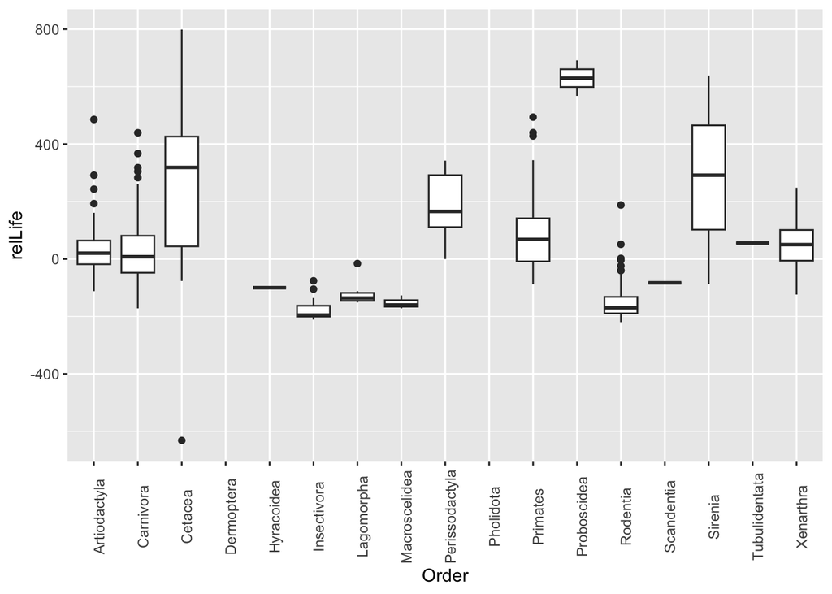

```r
p <- ggplot(data = newd, aes(x = `order`, y = `relLife` )) + geom_boxplot() + xlab("Order") +
    theme(axis.text.x = element_text(angle = 90))


plot(p)
```

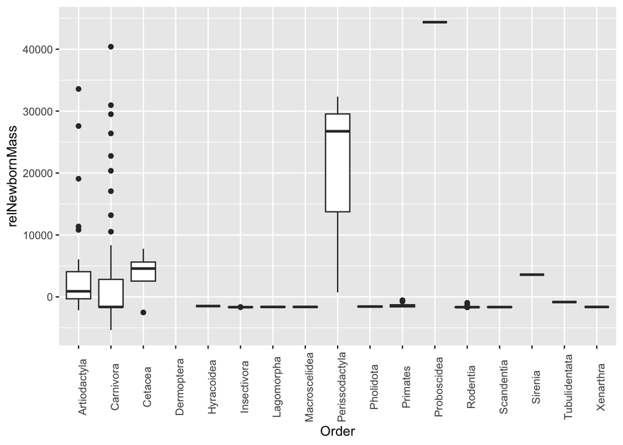

```r
p1 <- ggplot(data = newd, aes(x = `order`, y = `relNewbornMass` )) + geom_boxplot() + xlab("Order") +
    theme(axis.text.x = element_text(angle = 90))

plot(p1)
```

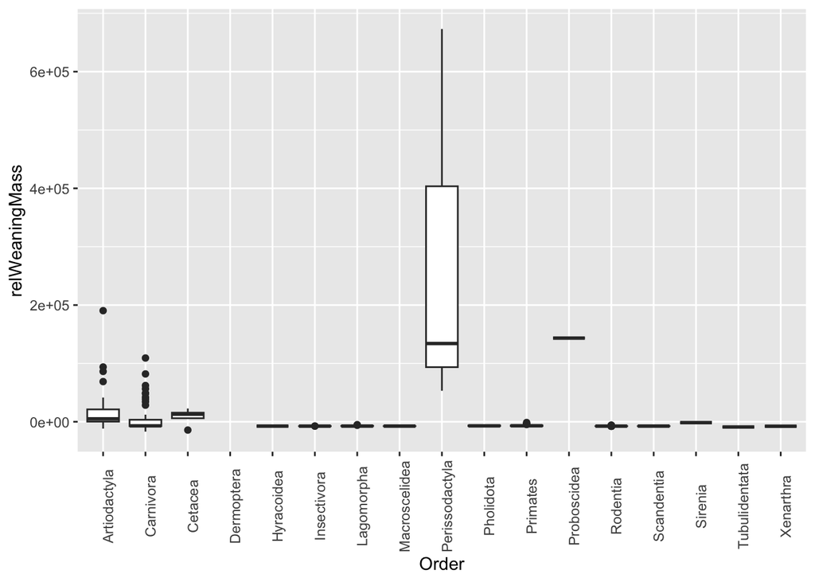

```r
p2 <- ggplot(data = newd, aes(x = `order`, y = `relWeaningMass` )) + geom_boxplot() + xlab("Order") +
    theme(axis.text.x = element_text(angle = 90))

plot(p2)
```

#Step 6

Run models and a model selection process to evaluate what (now log transformed) variables best predict each of the two response variables, max. life(mo) and AFR(mo), from the set of the following predictors: gestation(mo), newborn(g), weaning(mo), wean mass(g), litters/year, and overall body mass(g).

For each of the two response variables, indicate what is the best model overall based on AICc and how many models have a delta AICc of 4 or less?

What variables, if any, appear in all of this set of “top” models? Calculate and plot the model-averaged coefficients and their CIs across this set of top models.

```r
drop_na(newd)
```

```
## # A tibble: 206 × 18
##    order        family      Genus species `mass(g)` `gestation(mo)` `newborn(g)`
##    <chr>        <chr>       <chr> <chr>       <dbl>           <dbl>        <dbl>
##  1 Artiodactyla Antilocapr… Anti… americ…    45375             8.13        3246.
##  2 Artiodactyla Bovidae     Aepy… melamp…    41480             6.35        5093
##  3 Artiodactyla Bovidae     Bison bison     497667.            8.93       20000
##  4 Artiodactyla Bovidae     Gaze… subgut…    25500             5.37        2427.
##  5 Artiodactyla Bovidae     Kobus kob        58600             8.38        4938.
##  6 Artiodactyla Bovidae     Mado… kirkii      4877.            5.77         654
##  7 Artiodactyla Bovidae     Ovis  canade…    68167.            5.99        4267.
##  8 Artiodactyla Bovidae     Saiga tatari…    38250             4.94        3365.
##  9 Artiodactyla Bovidae     Sync… caffer    504667.           11.0        42862.
## 10 Artiodactyla Camelidae   Came… dromed…   434000            12.6        35808.
## # ℹ 196 more rows
## # ℹ 11 more variables: `weaning(mo)` <dbl>, `wean mass(g)` <dbl>,
## #   `AFR(mo)` <dbl>, `max. life(mo)` <dbl>, `litters/year` <dbl>,
## #   relGest <dbl>, relWean <dbl>, relAFR <dbl>, relLife <dbl>,
## #   relNewbornMass <dbl>, relWeaningMass <dbl>
```

```r
colnames(newd)
```

```
##  [1] "order"          "family"         "Genus"          "species"
##  [5] "mass(g)"        "gestation(mo)"  "newborn(g)"     "weaning(mo)"
##  [9] "wean mass(g)"   "AFR(mo)"        "max. life(mo)"  "litters/year"
## [13] "relGest"        "relWean"        "relAFR"         "relLife"
## [17] "relNewbornMass" "relWeaningMass"
```

```r
#FOR max. life (mo)
m <- lm(data = newd, `max. life(mo)` ~ `gestation(mo)`+ `newborn(g)`+ `weaning(mo)`+ `wean mass(g)`+ `litters/year`, + `mass(g)`)

(s <- stepAIC(m, scope = . ~ ., direction = "both"))
```

```
## Start:  AIC=880.55
## `max. life(mo)` ~ `gestation(mo)` + `newborn(g)` + `weaning(mo)` +
##     `wean mass(g)` + `litters/year`
##
##                   Df Sum of Sq    RSS    AIC
## - `newborn(g)`     1      6416 757154 879.37
## - `gestation(mo)`  1      7136 757873 879.47
## - `weaning(mo)`    1     11340 762077 880.00
## - `wean mass(g)`   1     13059 763796 880.22
## <none>                         750737 880.55
## - `litters/year`   1     75258 825996 887.81
##
## Step:  AIC=879.37
## `max. life(mo)` ~ `gestation(mo)` + `weaning(mo)` + `wean mass(g)` +
##     `litters/year`
##
##                   Df Sum of Sq    RSS    AIC
## - `weaning(mo)`    1      7368 764522 878.31
## - `gestation(mo)`  1     12916 770070 879.01
## <none>                         757154 879.37
## + `newborn(g)`     1      6416 750737 880.55
## - `litters/year`   1     82758 839912 887.44
## - `wean mass(g)`   1    189033 946187 898.99
##
## Step:  AIC=878.31
## `max. life(mo)` ~ `gestation(mo)` + `wean mass(g)` + `litters/year`
##
##                   Df Sum of Sq    RSS    AIC
## <none>                         764522 878.31
## - `gestation(mo)`  1     22955 787476 879.18
## + `weaning(mo)`    1      7368 757154 879.37
## + `newborn(g)`     1      2445 762077 880.00
## - `litters/year`   1    101570 866091 888.41
## - `wean mass(g)`   1    229787 994309 901.80
```

```
##
## Call:
## lm(formula = `max. life(mo)` ~ `gestation(mo)` + `wean mass(g)` +
##     `litters/year`, data = newd, subset = +`mass(g)`)
##
## Coefficients:
##     (Intercept)  `gestation(mo)`   `wean mass(g)`   `litters/year`
##       2.285e+02        6.793e+00        9.369e-04       -4.100e+01
```

```r
summary (s)
```

```
##
## Call:
## lm(formula = `max. life(mo)` ~ `gestation(mo)` + `wean mass(g)` +
##     `litters/year`, data = newd, subset = +`mass(g)`)
##
## Residuals:
##     Min      1Q  Median      3Q     Max
## -131.21  -57.06  -15.05   38.70  267.80
##
## Coefficients:
##                   Estimate Std. Error t value Pr(>|t|)
## (Intercept)      2.285e+02  2.969e+01   7.698 1.44e-11 ***
## `gestation(mo)`  6.793e+00  4.065e+00   1.671 0.098079 .
## `wean mass(g)`   9.369e-04  1.772e-04   5.287 8.19e-07 ***
## `litters/year`  -4.100e+01  1.166e+01  -3.515 0.000681 ***
## ---
## Signif. codes:  0 '***' 0.001 '**' 0.01 '*' 0.05 '.' 0.1 ' ' 1
##
## Residual standard error: 90.67 on 93 degrees of freedom
##   (1343 observations deleted due to missingness)
## Multiple R-squared:  0.6104, Adjusted R-squared:  0.5979
## F-statistic: 48.57 on 3 and 93 DF,  p-value: < 2.2e-16
```

```r
#For AFR(mo)
m2 <- lm(data = newd, `AFR(mo)` ~ `gestation(mo)`+ `newborn(g)`+ `weaning(mo)`+ `wean mass(g)`+ `litters/year`, + `mass(g)`)

(s2 <- stepAIC(m2, scope = . ~ ., direction = "both"))
```

```
## Start:  AIC=554.94
## `AFR(mo)` ~ `gestation(mo)` + `newborn(g)` + `weaning(mo)` +
##     `wean mass(g)` + `litters/year`
##
##                   Df Sum of Sq   RSS    AIC
## <none>                         13796 554.94
## - `wean mass(g)`   1     750.7 14547 558.93
## - `gestation(mo)`  1    1000.1 14796 560.85
## - `litters/year`   1    1138.4 14935 561.90
## - `newborn(g)`     1    2613.6 16410 572.54
## - `weaning(mo)`    1    6502.4 20299 596.57
```

```
##
## Call:
## lm(formula = `AFR(mo)` ~ `gestation(mo)` + `newborn(g)` + `weaning(mo)` +
##     `wean mass(g)` + `litters/year`, data = newd, subset = +`mass(g)`)
##
## Coefficients:
##     (Intercept)  `gestation(mo)`     `newborn(g)`    `weaning(mo)`
##      17.1793147       -1.5138943        0.0014113        2.8795467
##  `wean mass(g)`   `litters/year`
##      -0.0001298       -3.9488130
```

```r
summary(s2)
```

```
##
## Call:
## lm(formula = `AFR(mo)` ~ `gestation(mo)` + `newborn(g)` + `weaning(mo)` +
##     `wean mass(g)` + `litters/year`, data = newd, subset = +`mass(g)`)
##
## Residuals:
##     Min      1Q  Median      3Q     Max
## -16.352  -8.490  -2.526   4.723  41.452
##
## Coefficients:
##                   Estimate Std. Error t value Pr(>|t|)
## (Intercept)      1.718e+01  3.451e+00   4.979 2.47e-06 ***
## `gestation(mo)` -1.514e+00  5.436e-01  -2.785  0.00633 **
## `newborn(g)`     1.411e-03  3.135e-04   4.502 1.72e-05 ***
## `weaning(mo)`    2.880e+00  4.055e-01   7.101 1.42e-10 ***
## `wean mass(g)`  -1.298e-04  5.381e-05  -2.413  0.01752 *
## `litters/year`  -3.949e+00  1.329e+00  -2.971  0.00366 **
## ---
## Signif. codes:  0 '***' 0.001 '**' 0.01 '*' 0.05 '.' 0.1 ' ' 1
##
## Residual standard error: 11.36 on 107 degrees of freedom
##   (1327 observations deleted due to missingness)
## Multiple R-squared:  0.6749, Adjusted R-squared:  0.6597
## F-statistic: 44.42 on 5 and 107 DF,  p-value: < 2.2e-16
```

```r
detach(package:MASS)
library(AICcmodavg)
#aictab(list(m0, m1, m2), c("m0", "m1", "m2"))
detach(package:AICcmodavg)


#(mods.avg <- summary(model.avg(mods, subset = delta < 4, fit = TRUE)))
```